# Layout automation with python

### Thomas Ferreira de Lima

**Lightwave Lab, Princeton University**

**Feb 28, 2020**

https://github.com/thomaslima/2020-ELE559-workshop-zeropdk

Email: tlima@princeton.edu

# Demo preparation

## Two installation options

### 1. Your custom python installation (default)

If you have python 3.6+ installed in your computer and are comfortable with installing packages with pip, all we need is `pip install zeropdk`. This will not work with python 3.8 yet.

For this workshop, I recommend this solution. I had worked on the alternative solution (Docker) for a workshop in which I only had a few hours with the audience. But it is a pain to work with it long-term.

### 2. Docker Container (alternative solution)

For users without Python 3.6+ setup, I have prepared a docker container with all the necessary packages pre-installed. It is compatible with all OS and runs isolated from your installation. I've tested on macOS and Windows 10. Linux users should know what they're doing.

# Installation Instructions (Default)

### *** If you have issues following these instructions, please file an issue in https://github.com/thomaslima/2020-ELE559-workshop-zeropdk/issues and we will try to help.

We will use the same forum to field layout questions along the course.

## Installing python

We will need python version 3.6 or 3.7 to be able to install the packages we need for this workshop.

If this is the first time you're using python, it might be a bit difficult to install. There are three different OSes present in the workshop: Windows, macOS, and Linux. I have honestly not tested myself all combination of OS and python versions with our scripts. I would like to ask your help with that.

### Windows

This is the trickiest OS for python. But at the same time the most used. I believe one of the easiest way of installing it, and the way most scientists do, is to install anaconda. Follow installation instructions here: https://www.anaconda.com/distribution/. Then, you'll need to be able to install pip packages like `klayout` and `zeropdk`. If you install `zeropdk`, it will install `klayout` automatically. So in your anaconda prompt, or whatever it is that the entrypoint for python scripts is called, run `pip install zeropdk`.

### Linux (Ubuntu-like)

It should be very straightforward to install python3 in this distribution. Google "install python3.6 on ubuntu" or "install python3.7 on ubuntu" and you'll find instructive websites like these: https://docs.python-guide.org/starting/install3/linux/. It should be a matter of running the following in the terminal:

```
sudo apt-get update
sudo apt-get install python3.6
```

### macOS

Many users also use anaconda (see instructions for Windows). But I personally prefer a more lightweight approach using Homebrew. I would use something resembling this tutorial instructions: https://docs.python-guide.org/starting/install3/osx/. For the purposes of this tutorial, you don't need to worry about virtual environments, but I do recommend learning about them if you're serious about running python in the future.

## Verify python version

In your command prompt, you should run `python --version` and confirm that you have either python 3.6 or 3.7 installed.

```
> python --version
Python 3.7.4
```

You might need to run `python3 --version` instead:

[output not shown]

## Installing zeropdk

In your command prompt, run `pip install zeropdk`. It's that simple. It should install the `klayout` python package along with it.

## Installing klayout

[Install klayout](https://www.klayout.de/build.html) so we can view the output of our scripts. If you have another layout viewer/editor, you may use that. In electronics, people are more comfortable with cadence software and the like. But I recommend you install klayout at least for the duration of this course.

# The end -- stop here

If you've reached here, you can stop. We should continue in class. But if you want to do an extra step, please proceed with the following.

## Verify that everything works

1. Clone or download the material from https://github.com/thomaslima/2020-ELE559-workshop-zeropdk.
2. Navigate to the folder `demo` with your command prompt that has python installed (Anaconda prompt or Terminal).
3. Run `python main_python.py`. It should generate a file called `example_mask.gds`.
4. Open the file with *KLayout*.

# Installation Instructions (More detailed)

## Python 3

I write all my scripts using python 3.6+ in mind. I did not pay special attention to backwards compatibility with earlier versions. Fixing syntax bugs should be straightforward if you are experienced with python. If you need to use the packages or demos presented here, feel free to submit a pull request to the relevant repositories.

## KLayout

[KLayout](https://www.klayout.de) is an open-source viewer and editor of IC layout files. It has a programming interface with Python and Ruby programming lanaguages. Recently, a pip package was released for the following python distributions:

| OS | Python Version |
| --- | --- |
| macOS 10.11+ | 2.7, 3.7 |
| macOS 10.13+ | 3.5, 3.6 |
| linux x64, x32 | 2.7, 3.5, 3.6, 3.6 |
| win32, win64 | 3.5, 3.6, 3.7 |

*Note for advanced users:* You can attempt to build klayout from source by running `python setup.py install` on the cloned folder from [klayout's github repo](https://github.com/KLayout/klayout).

## Zeropdk

Zeropdk is a python opensource package with basic tools for photonics layout based on the klayout database engine. It is akin to SiEPIC-tools but it was written so that it could be compatible with any foundry's layer stacks. It can also be installed with pip via `pip install zeropdk`. Alternatively, install from source via [the github repo](https://github.com/lightwave-lab/zeropdk). Documentation is scarce at the moment but hopefully this workshop will be a good start.

## Meta: Adapting the docker container to your demo

If you like Docker and want to build your own Docker image (opensource or closed source), I put the recipe (called *Dockerfile*) inside the `docker-image` folder.

# Installation Instructions (Alternative Solution)

## Docker

I have prepared a docker container with all the necessary packages pre-installed. It is compatible with all OS and runs isolated from your installation.

### Docker requirements:

#### Windows Requirements:

- Windows 10 64-bit: Pro, Enterprise, or Education (Build 15063 or later).
- Hyper-V and Containers Windows features must be enabled.
- The following hardware prerequisites are required to successfully run Client Hyper-V on Windows 10:
  - 64 bit processor with Second Level Address Translation (SLAT)
  - 4GB system RAM
  - BIOS-level hardware virtualization support must be enabled in the BIOS settings. For more information, see Virtualization.

#### macOS Requirements:

- Mac hardware must be a 2010 or newer model, with Intel’s hardware support for memory management unit (MMU) virtualization, including Extended Page Tables (EPT) and Unrestricted Mode. You can check to see if your machine has this support by running the following command in a terminal: sysctl kern.hv_support
- macOS must be version 10.13 or newer. We recommend upgrading to the latest version of macOS.
  - If you experience any issues after upgrading your macOS to version 10.15, you must install the latest version of Docker Desktop to be compatible with this version of macOS.
- At least 4 GB of RAM.
- VirtualBox prior to version 4.3.30 must not be installed as it is not compatible with Docker Desktop.

### 1. Download Docker:

- [macOS](https://download.docker.com/mac/stable/Docker.dmg)
- [Windows download](https://download.docker.com/win/stable/Docker%20for%20Windows%20Installer.exe)
  - **Note:** on Windows, the installation will require you to **sign out** and sign in, so save all your work!

### 2. Install Docker

The first time you start Docker it will pop up a dialog telling you you need an account. You do **not** need an account. Close the dialog that tells you this: Docker is already running and fully functional. There are [thousands of people](https://github.com/docker/docker.github.io/issues/6910) complaining about the fact that they try to force you to login in order to download/use it.

### 3. Pull docker image from docker.io

Open your command line terminal (cmd in Windows) and type:

```
docker pull felimath/zeropdk
```

You can check the Docker Image with

```
docker images
```

It should show:

```
REPOSITORY                 TAG                 IMAGE ID            CREATED              SIZE
felimath/zeropdk           latest              1082ad385453        About a minute ago   1.42GB
...
```

This demo's image id: **1082ad385453**.

### 4. Navigate to the demo folder, downloaded from github.

Download the demo files from the [workshop's github repo](https://github.com/thomaslima/2019-siepic-workshop-zeropdk) and navigate to the demo folder.

#### (Option 1) Using git:

```
git clone https://github.com/thomaslima/2019-siepic-workshop-zeropdk.git ~/2019-siepic-workshop-zeropdk
```

If you have cloned the repo, navigate to `~/2019-siepic-workshop-zeropdk/demo` with:

```
cd ~/2019-siepic-workshop-zeropdk/demo
```

#### (Option 2) Download zipped file:

If you don't have git (Windows, or any other reason), feel free to download a [zip file directly from github](https://github.com/thomaslima/2019-siepic-workshop-zeropdk/archive/master.zip). In my computer, I extracted to the default location and used the following command to get there:

```
# windows
cd Downloads\2019-siepic-workshop-zeropdk-master\2019-siepic-workshop-zeropdk-master\demo

# bash (unix)
cd ~/Downloads/2019-siepic-workshop-zeropdk-master/demo
```

### 5. Run the jupyter notebook start script.

From within the demo folder, run the following command in your console

```
# windows
start-jupyter-windows.bat
# unix
./start-jupyter-unix.sh
```

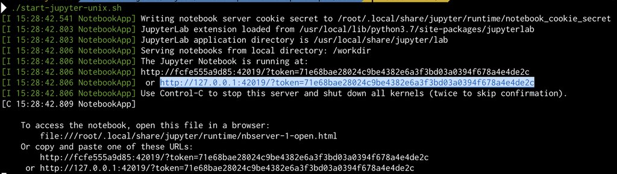

### Final step:

Open a browser and go to the highlighted address as shown above. In my case, it was `http://127.0.0.1:42019/?token=71e68bae28024c9be4382e6a3f3bd03a0394f678a4e4de2c`, but yours will have a different token.